# DS01-IU 8-Nizam

Assessment : 08

Title: Seaborn Visualizations Assessment

Introduction: Welcome to the Seaborn Visualizations Assessment! In this assessment, you will demonstrate your understanding of Seaborn and its various visualization techniques. You will be tested on your ability to create and interpret Seaborn plots. Let's get started!

Task 1: Box Plots

Create a Box Plot using Seaborn to visualize the distribution of a numerical variable across different categories. Explain the components of a Box Plot and their significance. Interpret the insights gained from the Box Plot.

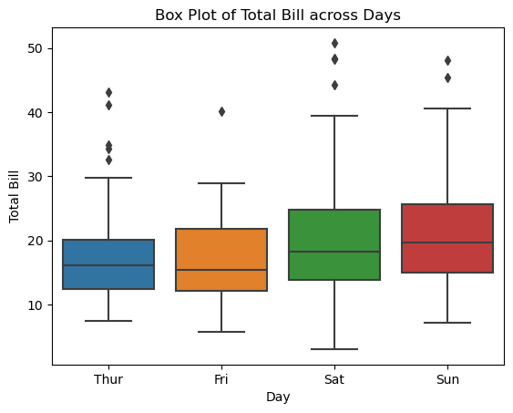

```python
import numpy as np
import pandas as pd
import seaborn as sns
import matplotlib.pyplot as plt

#In this code, we load the 'tips' dataset from Seaborn using the
#sns.load_dataset() function. We create the box plot using
#sns.boxplot() and specify the 'day' column as the x-axis and the
#'total_bill' column as the y-axis.

#We add labels to the x-axis and y-axis using plt.xlabel() and
#plt.ylabel(), respectively. The title of the plot is set using plt.title().
#plt.show() to display the box plot.



# Load the 'tips' dataset from Seaborn
data = sns.load_dataset('tips')

# Create the box plot
sns.boxplot(x='day', y='total_bill', data=data)

# Add labels and title
plt.xlabel('Day')
plt.ylabel('Total Bill')
plt.title('Box Plot of Total Bill across Days')

# Display the plot
plt.show()
```

Task 2: KDE Plots

Create a Kernel Density Estimate (KDE) Plot using Seaborn to visualize the density of a numerical variable. Describe the concept of kernel density estimation. Analyze the shape of the density curve and draw conclusions from the KDE Plot.

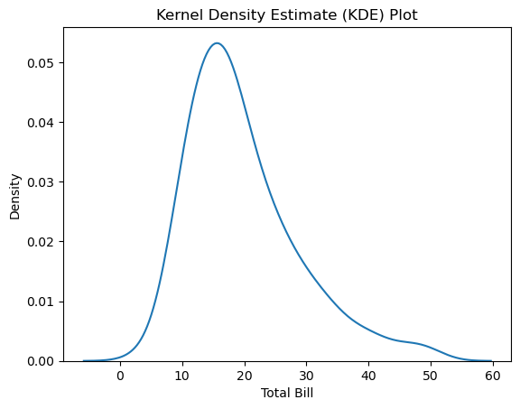

```python
#In this code, we load the 'tips' dataset using
#sns.load_dataset('tips'). We then create the KDE plot using
#sns.kdeplot() and specify the 'total_bill' column as the variable to visualize.

#Labels for the x-axis and y-axis are added using plt.xlabel() and
#plt.ylabel(), respectively. The title of the plot is set using plt.title().

# Load the 'tips' dataset from Seaborn
data = sns.load_dataset('tips')

# Create the KDE plot
sns.kdeplot(data=data['total_bill'])

# Add labels and title
plt.xlabel('Total Bill')
plt.ylabel('Density')
plt.title('Kernel Density Estimate (KDE) Plot')

# Display the plot
plt.show()
```

Task 3: Violin Plots

Create a Violin Plot using Seaborn to explore the distribution of a numerical variable based on different categories. Compare Violin Plots to Box Plots and explain their differences. Interpret the summary statistics and density shapes from the Violin Plot.

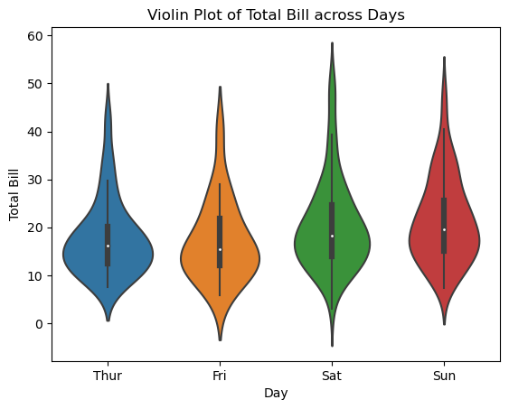

```python
#In this code snippet, we are using the 'tips' dataset from Seaborn,
#which is loaded using the sns.load_dataset('tips') function.

#To create the KDE plot, we use the sns.kdeplot() function and
#specify the 'total_bill' column as the variable to visualize. This function
#generates the kernel density estimation plot for the specified variable.

#Labels for the x-axis and y-axis are added using plt.xlabel() and
#plt.ylabel(), respectively. These functions allow us to provide a descriptive label for each axis.

#set the title of the plot using plt.title(), which allows us to give a meaningful title to the plot.

#By incorporating these additional components (labels and title) into
#the plot, we enhance its clarity and provide context to the viewers.


# Load the 'tips' dataset from Seaborn
data = sns.load_dataset('tips')

# Create the Violin Plot
sns.violinplot(x='day', y='total_bill', data=data)

# Add labels and title
plt.xlabel('Day')
plt.ylabel('Total Bill')
plt.title('Violin Plot of Total Bill across Days')

# Display the plot
plt.show()
```

Task 4: Heatmaps

Create a Heatmap using Seaborn to visualize the correlation matrix between numerical variables. Discuss the importance of using color maps in Heatmaps. Analyze the Heatmap to identify patterns and relationships between variables.

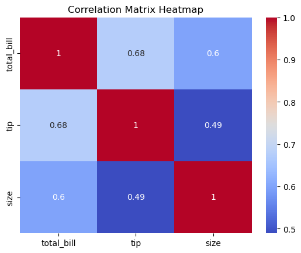

```python
#load the 'tips' dataset using sns.load_dataset('tips').

#To calculate the correlation matrix, we use the corr() function on
#the 'tips' dataset. This function calculates the pairwise correlations
#between all numerical variables in the dataset and returns a correlation matrix.

#the correlation_matrix as the data argument to create a heatmap based on the correlation values.
#The annot=True parameter adds the correlation values to each cell of the heatmap for better readability.
#The cmap='coolwarm' parameter sets the color map for the heatmap, where 'coolwarm'

#add a title to the heatmap using plt.title() to provide a descriptive title for the plot.

#use plt.show() to display the heatmap plot.
#heatmap visualizes the correlation matrix, allowing us to identify
#patterns and relationships between numerical variables.



# Load the 'tips' dataset from Seaborn
data = sns.load_dataset('tips')

# Calculate the correlation matrix
correlation_matrix = data.corr()

# Create the Heatmap
sns.heatmap(correlation_matrix, annot=True, cmap='coolwarm')

# Add title
plt.title('Correlation Matrix Heatmap')

# Display the plot
plt.show()
```